# Data Exploration & Preparation - CA1 Project

Chia Hua Lin-2020044 & Ruei Li Jhang-2020443

## About the Dataset

The data is about Coronavirus (COVID-19) Vaccinations

The website states that the vaccine dataset is based on the most current official data from international health ministries and governments. The United Nations World Population Prospects serve as the basis for population estimates used in per-capita measurements. Based on the World Bank classification, income groups are created. Source: https://ourworldindata.org/covid-vaccinations

```r
# Load required libraries
library(tidyverse)
library(lares) # show the structure of data
library(vtable) # show the mean, sd, min, max
library(caret)
library(psycho) # Standardizing
library('DescTools')
library(ggcorrplot)
library(plotly) # Using plotly for interactive plots
library(fastDummies) # for dummy encoding
```

## Loading the dataset

```r
# Loading the data after downloading
data <- read.csv("owid-covid-data.csv")
dim(data)
```

```
## [1] 351787     67
```

```r
# Overview of the data
head(data, 5)
```

```
##   iso_code continent    location       date total_cases new_cases
## 1      AFG      Asia Afghanistan 2020-01-03          NA         0
## 2      AFG      Asia Afghanistan 2020-01-04          NA         0
## 3      AFG      Asia Afghanistan 2020-01-05          NA         0
## 4      AFG      Asia Afghanistan 2020-01-06          NA         0
## 5      AFG      Asia Afghanistan 2020-01-07          NA         0
##   new_cases_smoothed total_deaths new_deaths new_deaths_smoothed
## 1                 NA           NA          0                  NA
## 2                 NA           NA          0                  NA
## 3                 NA           NA          0                  NA
## 4                 NA           NA          0                  NA
## 5                 NA           NA          0                  NA
##   total_cases_per_million new_cases_per_million new_cases_smoothed_per_million
## 1                      NA                     0                             NA
## 2                      NA                     0                             NA
```

[output cut: 111 more lines]

```r
str(data)
```

```
## 'data.frame':    351787 obs. of  67 variables:
##  $ iso_code                                  : chr  "AFG" "AFG" "AFG" "AFG" ...
##  $ continent                                 : chr  "Asia" "Asia" "Asia" "Asia" ...
##  $ location                                  : chr  "Afghanistan" "Afghanistan" "Afghanistan" "Afghanistan" ...
##  $ date                                      : chr  "2020-01-03" "2020-01-04" "2020-01-05" "2020-01-06" ...
##  $ total_cases                               : num  NA NA NA NA NA NA NA NA NA NA ...
##  $ new_cases                                 : num  0 0 0 0 0 0 0 0 0 0 ...
##  $ new_cases_smoothed                        : num  NA NA NA NA NA 0 0 0 0 0 ...
##  $ total_deaths                              : num  NA NA NA NA NA NA NA NA NA NA ...
##  $ new_deaths                                : num  0 0 0 0 0 0 0 0 0 0 ...
##  $ new_deaths_smoothed                       : num  NA NA NA NA NA 0 0 0 0 0 ...
##  $ total_cases_per_million                   : num  NA NA NA NA NA NA NA NA NA NA ...
##  $ new_cases_per_million                     : num  0 0 0 0 0 0 0 0 0 0 ...
##  $ new_cases_smoothed_per_million            : num  NA NA NA NA NA 0 0 0 0 0 ...
##  $ total_deaths_per_million                  : num  NA NA NA NA NA NA NA NA NA NA ...
```

[output cut: 53 more lines]

### Checking for missing values

```r
# Check for null values in the dataframe
is_null <- is.na(data)

# Count the number of null values in each column
num_null_values <- colSums(is_null, na.rm = TRUE)

# Print the number of null values in each column
print(num_null_values)
```

```
##                                   iso_code
##                                          0
##                                  continent
##                                          0
##                                   location
##                                          0
##                                       date
##                                          0
##                                total_cases
##                                      37991
##                                  new_cases
##                                       9611
##                         new_cases_smoothed
##                                      10870
##                               total_deaths
##                                      59620
##                                 new_deaths
##                                       9560
##                        new_deaths_smoothed
##                                      10790
##                    total_cases_per_million
##                                      37991
##                      new_cases_per_million
##                                       9611
##             new_cases_smoothed_per_million
##                                      10870
##                   total_deaths_per_million
##                                      59620
##                     new_deaths_per_million
##                                       9560
##            new_deaths_smoothed_per_million
##                                      10790
##                          reproduction_rate
##                                     166970
##                               icu_patients
##                                     314132
##                   icu_patients_per_million
##                                     314132
##                              hosp_patients
##                                     312824
```

[output cut: 79 more lines]

```
##                                     110924
##                            life_expectancy
##                                      28126
##                    human_development_index
##                                      87343
##                                 population
##                                          0
##       excess_mortality_cumulative_absolute
##                                     339582
##                excess_mortality_cumulative
##                                     339582
##                           excess_mortality
##                                     339582
##    excess_mortality_cumulative_per_million
##                                     339582
```

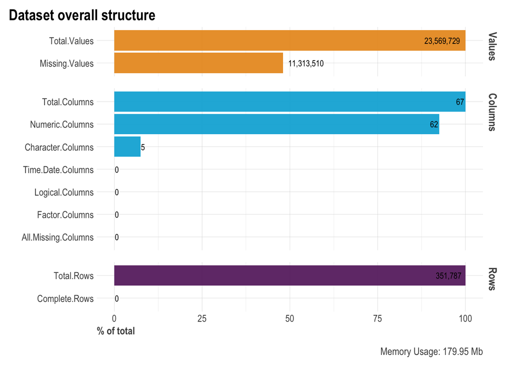

```r
# show the details of the dataset
df_str(data, return = "plot")
```

As we can see from the above output, there are columns with a very high number of null values. So the first thing would be to drop all the columns whose number of null values is more more than half the total number of rows, or observations.

**Sometimes, R do not read empty strings, and question marks as nulls. So we first convert the Question marks and the empty strings as nulls then check the number of null values.

```r
# Replace question marks with NA in the entire dataframe
data[data == "?"] <- NA

# Replace empty strings with NA in the entire dataframe
data[data == ""] <- NA

# Check for null values in each column
null_counts <- colSums(is.na(data))

# Get columns where more than half of the values are null
columns_to_drop <- names(null_counts[null_counts > nrow(data)/2])

# Drop columns with more than half of the values being null
data <- data[, !names(data) %in% columns_to_drop]

dim(data)
```

```
## [1] 351787     35
```

```r
# Drop rows with NA values using na.omit()
data <- na.omit(data)

# Check for null values in the dataframe
is_null <- is.na(data)

# Count the number of null values in each column
num_null_values <- colSums(is_null, na.rm = TRUE)

# Print the number of null values in each column
print(num_null_values)
```

```
##                                   iso_code
##                                          0
##                                  continent
##                                          0
##                                   location
##                                          0
##                                       date
##                                          0
##                                total_cases
##                                          0
##                                  new_cases
##                                          0
##                         new_cases_smoothed
##                                          0
##                               total_deaths
##                                          0
##                                 new_deaths
##                                          0
##                        new_deaths_smoothed
##                                          0
##                    total_cases_per_million
##                                          0
##                      new_cases_per_million
##                                          0
##             new_cases_smoothed_per_million
##                                          0
##                   total_deaths_per_million
##                                          0
##                     new_deaths_per_million
##                                          0
##            new_deaths_smoothed_per_million
##                                          0
##                          reproduction_rate
##                                          0
##                  new_vaccinations_smoothed
##                                          0
##      new_vaccinations_smoothed_per_million
##                                          0
##             new_people_vaccinated_smoothed
##                                          0
```

[output cut: 15 more lines]

```
##                                          0
##                        diabetes_prevalence
##                                          0
##                             female_smokers
##                                          0
##                               male_smokers
##                                          0
##                 hospital_beds_per_thousand
##                                          0
##                            life_expectancy
##                                          0
##                    human_development_index
##                                          0
##                                 population
##                                          0
```

```r
View(data)
```

We can now see that we do not have any null values in the columns.

### Dropping all the Null Values

```r
# Drop rows with NA values using na.omit()
data_clean <- na.omit(data)

# checking the shape of the data
cat('The shape of the data:', dim(data_clean)[1], 'rows/observations', 'and', dim(data_clean)[2], 'columns')
```

```
## The shape of the data: 80318 rows/observations and 35 columns
```

### Removing Unwanted Columns

```r
# Removing a single column using subset() function
data <- subset(data, select = -c(population, human_development_index, life_expectancy, hospital_beds_per_thousand, male_smokers, female_smokers,
diabetes_prevalence, cardiovasc_death_rate, gdp_per_capita, aged_70_older, aged_65_older, median_age, population_density, stringency_index, new_people_vaccinated_smoothed_per_hundred, new_vaccinations_smoothed_per_million, new_deaths_smoothed_per_million, new_deaths_per_million, total_deaths_per_million, new_cases_smoothed_per_million, new_cases_per_million, total_cases_per_million))

dim(data)
```

```
## [1] 80318    13
```

### A. Identify which variables are categorical, discrete and continuous in the chosen data set and show using some visualization or plot. Explore whether there are missing values for any of the variables.

```r
# Remove all instances of 0 from all columns
data_no_zeros <- data
data_no_zeros[data_no_zeros == 0] <- NA
data <- na.omit(data_no_zeros)

# Check data types of variables
str(data)
```

```
## 'data.frame':    43428 obs. of  13 variables:
##  $ iso_code                      : chr  "ALB" "ALB" "ALB" "ALB" ...
##  $ continent                     : chr  "Europe" "Europe" "Europe" "Europe" ...
##  $ location                      : chr  "Albania" "Albania" "Albania" "Albania" ...
##  $ date                          : chr  "2021-01-11" "2021-01-12" "2021-01-13" "2021-01-14" ...
##  $ total_cases                   : num  63033 63595 63971 64627 65334 ...
##  $ new_cases                     : num  655 562 376 656 707 660 641 581 474 292 ...
##  $ new_cases_smoothed            : num  577 594 621 621 618 ...
##  $ total_deaths                  : num  1233 1241 1247 1252 1256 ...
##  $ new_deaths                    : num  3 8 6 5 4 5 4 5 7 4 ...
##  $ new_deaths_smoothed           : num  6.14 6.86 6.86 6 5.57 ...
##  $ reproduction_rate             : num  1.06 1.07 1.07 1.07 1.07 1.07 1.07 1.08 1.09 1.1 ...
##  $ new_vaccinations_smoothed     : num  64 64 63 66 62 62 58 55 51 47 ...
##  $ new_people_vaccinated_smoothed: num  64 64 63 66 62 62 58 55 51 47 ...
##  - attr(*, "na.action")= 'omit' Named int [1:36890] 18 19 20 21 22 23 138 139 144 145 ...
##   ..- attr(*, "names")= chr [1:36890] "3176" "3177" "3178" "3179" ...
```

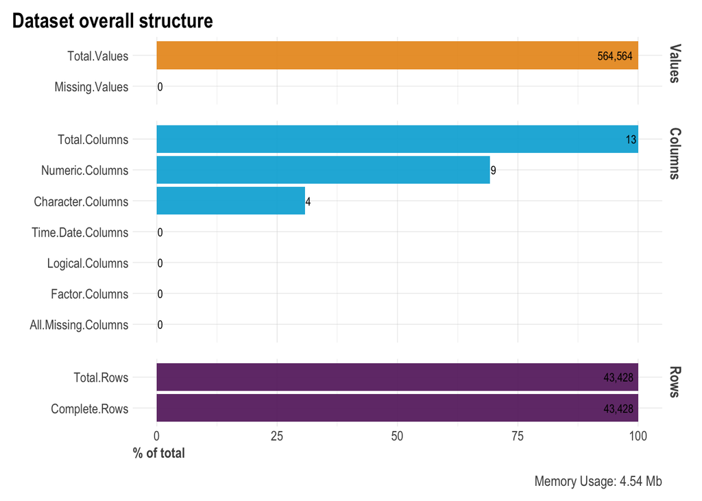

```r
# show the details of the dataset
df_str(data, return = "plot")
```

### Identify which variables are categorical, discrete and continuous in the chosen data set

-`Categorical Variables`

- iso_code
- continent
- location
- date

-`Discrete Variables`

- total_cases
- new_cases
- total_deaths
- new_deaths
- new_vaccinations_smoothed
- new_people_vaccinated_smoothed

-`Continous Variables`

- new_cases_smoothed
- new_deaths_smoothed
- reproduction_rate

### B. Calculate the statistical parameters (mean, median, minimum, maximum, and standard deviation) for each of the numerical variables.

```r
# Select numerical columns using indexing
numerical_data <- data[sapply(data, is.numeric)]

numerical_data  %>%
      pivot_longer(everything()) %>%
      group_by(name) %>%
      summarise_at(vars(value), list(Mean = mean, Median = median, Min = min,  Max = max, Sd = sd))
```

```
## # A tibble: 9 × 6
##   name                                  Mean    Median     Min       Max      Sd
##   <chr>                                <dbl>     <dbl>   <dbl>     <dbl>   <dbl>
## 1 new_cases                        13950.      1545      1        6.97e6 1.04e+5
## 2 new_cases_smoothed               11284.      1497.     0.143    5.88e6 8.82e+4
## 3 new_deaths                         101.        14      1        1.14e4 3.30e+2
## 4 new_deaths_smoothed                 90.1       13.1    0.143    4.19e3 2.83e+2
## 5 new_people_vaccinated_smoothed   87454.      7177      1        6.79e6 3.77e+5
## 6 new_vaccinations_smoothed       214364.     25939      1        2.24e7 8.55e+5
## 7 reproduction_rate                    0.994      0.97  -0.03     4.22e0 2.95e-1
## 8 total_cases                    4084958.    839881    129        9.94e7 9.96e+6
## 9 total_deaths                     61070.     12374.     1        1.08e6 1.40e+5
```

```r
# getting the summary statistics
st(numerical_data)
```

Summary Statistics

| Variable | N | Mean | Std. Dev. | Min | Pctl. 25 | Pctl. 75 | Max |
| --- | --- | --- | --- | --- | --- | --- | --- |
| total_cases | 43428 | 4084958 | 9958820 | 129 | 278548 | 3488102 | 99411696 |
| new_cases | 43428 | 13950 | 103615 | 1 | 406 | 6422 | 6966046 |
| new_cases_smoothed | 43428 | 11284 | 88184 | 0.14 | 410 | 5975 | 5882129 |
| total_deaths | 43428 | 61070 | 140487 | 1 | 3583 | 36870 | 1082456 |
| new_deaths | 43428 | 101 | 330 | 1 | 4 | 56 | 11447 |
| new_deaths_smoothed | 43428 | 90 | 283 | 0.14 | 3.6 | 54 | 4190 |
| reproduction_rate | 43428 | 0.99 | 0.29 | -0.03 | 0.81 | 1.1 | 4.2 |
| new_vaccinations_smoothed | 43428 | 214364 | 854845 | 1 | 5654 | 120608 | 22424286 |
| new_people_vaccinated_smoothed | 43428 | 87454 | 377164 | 1 | 1042 | 37637 | 6785334 |

### C. Apply Min-Max Normalization, Z-score Standardization and Robust scalar on the numerical data variables.

#### Min-Max Normalization

```r
# Apply Min-Max Normalization
preproc <- preProcess(numerical_data, method = c("range"))
scaled_data_minmax <- predict(preproc, numerical_data)
head(scaled_data_minmax, 10)
```

```
##       total_cases    new_cases new_cases_smoothed total_deaths   new_deaths
## 3159 0.0006327634 9.388398e-05       9.814237e-05  0.001138154 0.0001747335
## 3160 0.0006384167 8.053350e-05       1.009352e-04  0.001145544 0.0006115674
## 3161 0.0006421989 5.383255e-05       1.055740e-04  0.001151087 0.0004368338
## 3162 0.0006487977 9.402753e-05       1.054768e-04  0.001155706 0.0003494671
## 3163 0.0006559096 1.013488e-04       1.050397e-04  0.001159402 0.0002621003
## 3164 0.0006625487 9.460174e-05       1.041410e-04  0.001164021 0.0003494671
## 3165 0.0006689966 9.187423e-05       1.033639e-04  0.001167716 0.0002621003
## 3166 0.0006748410 8.326102e-05       1.015666e-04  0.001172335 0.0003494671
## 3167 0.0006796090 6.790080e-05       9.942948e-05  0.001178802 0.0005242006
## 3168 0.0006825463 4.177406e-05       9.738941e-05  0.001182497 0.0002621003
##      new_deaths_smoothed reproduction_rate new_vaccinations_smoothed
## 3159         0.001432030         0.2564706              2.809454e-06
## 3160         0.001602441         0.2588235              2.809454e-06
## 3161         0.001602441         0.2588235              2.764860e-06
```

[output cut: 18 more lines]

#### Z-score Standardization

```r
# Z-score standardization
z_score_standardized_data <- as.data.frame(scale(numerical_data))
head(z_score_standardized_data, 10)
```

```
##      total_cases  new_cases new_cases_smoothed total_deaths new_deaths
## 3159  -0.4038556 -0.1283085         -0.1214125   -0.4259262 -0.2968933
## 3160  -0.4037992 -0.1292061         -0.1212263   -0.4258692 -0.2817319
## 3161  -0.4037614 -0.1310012         -0.1209168   -0.4258265 -0.2877964
## 3162  -0.4036955 -0.1282989         -0.1209233   -0.4257909 -0.2908287
## 3163  -0.4036245 -0.1278067         -0.1209525   -0.4257624 -0.2938610
## 3164  -0.4035583 -0.1282603         -0.1210124   -0.4257269 -0.2908287
## 3165  -0.4034939 -0.1284437         -0.1210642   -0.4256984 -0.2938610
## 3166  -0.4034356 -0.1290227         -0.1211841   -0.4256628 -0.2908287
## 3167  -0.4033880 -0.1300554         -0.1213267   -0.4256130 -0.2847641
## 3168  -0.4033587 -0.1318119         -0.1214628   -0.4255845 -0.2938610
##      new_deaths_smoothed reproduction_rate new_vaccinations_smoothed
## 3159          -0.2971834         0.2249132                -0.2506890
## 3160          -0.2946569         0.2588510                -0.2506890
## 3161          -0.2946569         0.2588510                -0.2506902
```

[output cut: 18 more lines]

#### Robust scalar

```r
# Robust Scalar
robust_scalar <- function(x){(x- median(x)) /(quantile(x,probs = .75)-quantile(x,probs = .25))}
robust_scalar_data <- as.data.frame(sapply(numerical_data, robust_scalar))
head(robust_scalar_data, 10)
```

```
##    total_cases  new_cases new_cases_smoothed total_deaths new_deaths
## 1   -0.2420424 -0.1479388         -0.1652539   -0.3347128 -0.2115385
## 2   -0.2418673 -0.1633976         -0.1623023   -0.3344724 -0.1153846
## 3   -0.2417501 -0.1943152         -0.1574000   -0.3342922 -0.1538462
## 4   -0.2415457 -0.1477726         -0.1575028   -0.3341420 -0.1730769
## 5   -0.2413254 -0.1392952         -0.1579647   -0.3340218 -0.1923077
## 6   -0.2411198 -0.1471077         -0.1589144   -0.3338716 -0.1730769
## 7   -0.2409201 -0.1502660         -0.1597356   -0.3337514 -0.1923077
## 8   -0.2407391 -0.1602394         -0.1616351   -0.3336012 -0.1730769
## 9   -0.2405914 -0.1780253         -0.1638936   -0.3333909 -0.1346154
## 10  -0.2405004 -0.2082779         -0.1660496   -0.3332707 -0.1923077
##    new_deaths_smoothed reproduction_rate new_vaccinations_smoothed
## 1             -0.14000         0.2647059                -0.2250905
## 2             -0.12572         0.2941176                -0.2250905
## 3             -0.12572         0.2941176                -0.2250992
```

[output cut: 18 more lines]

### D. Line, Scatter and Heatmaps can be used to show the correlation between the features of the dataset.

#### Total Cases vs Total Deaths

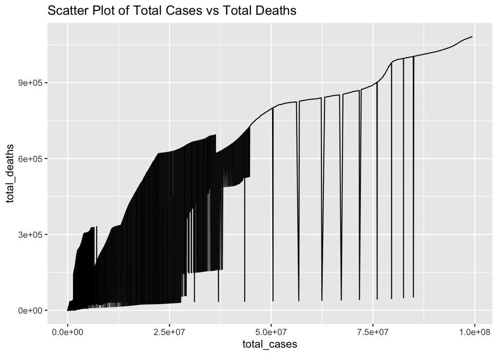

```r
# Basic line plot
ggplot(data=data, aes(x=total_cases, y=total_deaths))+
  geom_line(color= 'black') +
  labs(title = "Scatter Plot of Total Cases vs Total Deaths")
```

#### Line Chart of New Deaths and New Deaths Smoothed

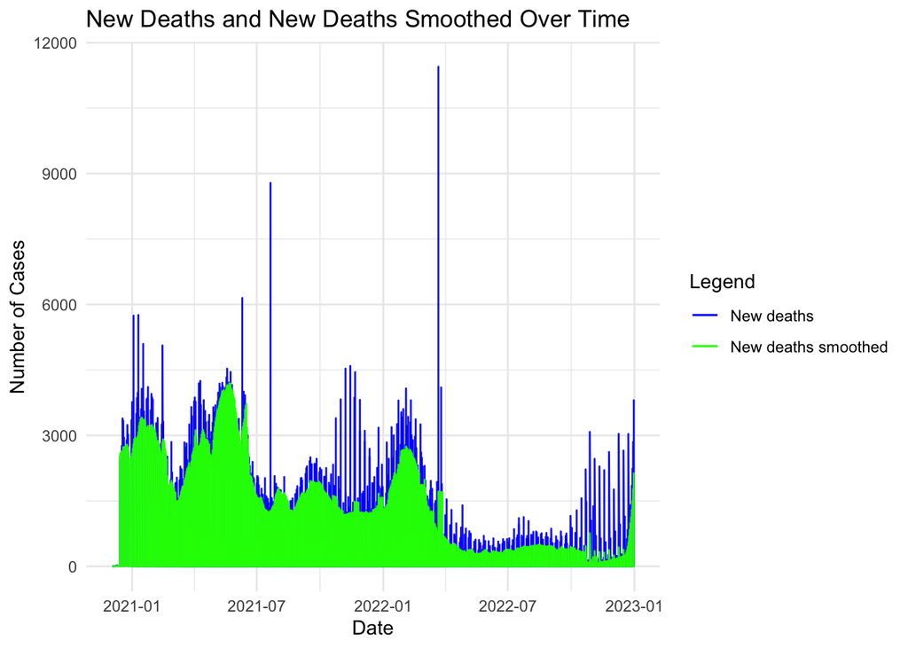

```r
# Convert 'date' column to Date type if it's not already
data$date <- as.Date(data$date)

# Plot 'new deaths' and 'new deaths smoothed' against dates with different colors for each line
ggplot(data, aes(x = date)) +
  geom_line(aes(y = new_deaths, color = "New deaths")) +
  geom_line(aes(y = new_deaths_smoothed, color = "New deaths smoothed")) +
  scale_color_manual(values = c("New deaths" = "blue", "New deaths smoothed" = "green")) +
  labs(title = "New Deaths and New Deaths Smoothed Over Time", x = "Date", y = "Number of Cases", color = "Legend") +
  theme_minimal()
```

#### Line Chart of Total Cases VS Total Deaths With Time

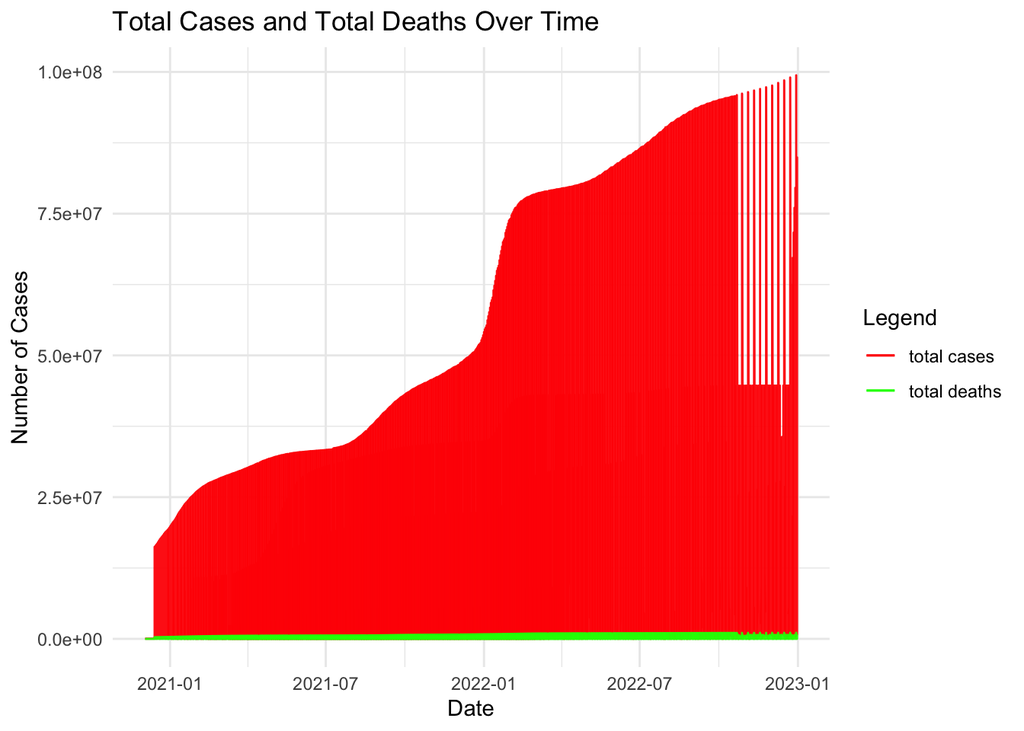

```r
# Convert 'date' column to Date type if it's not already
ggplot(data, aes(x = date)) +
  geom_line(aes(y = total_cases, color = "total cases")) +
  geom_line(aes(y = total_deaths, color = "total deaths")) +
  scale_color_manual(values = c("total cases" = "red", "total deaths" = "green")) +
  labs(title = "Total Cases and Total Deaths Over Time", x = "Date", y = "Number of Cases", color = "Legend") +
  theme_minimal()
```

#### Scatter Plot of Total Deaths Vs Total Cases

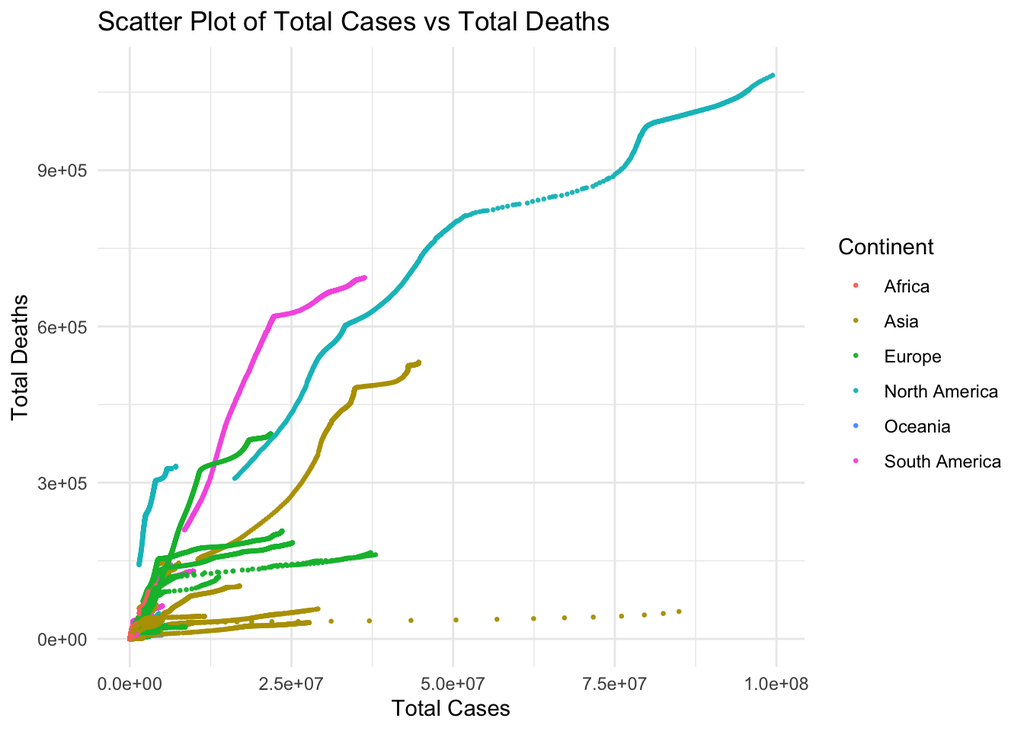

```r
# Plot scatter plot of 'total_cases' vs 'total_deaths' with different colors for each data point
ggplot(data, aes(x = total_cases, y = total_deaths, color = factor(continent))) +
  geom_point(size = 0.5) +
  labs(title = "Scatter Plot of Total Cases vs Total Deaths",
       x = "Total Cases", y = "Total Deaths", color = "Continent") +
  theme_minimal()
```

#### Heatmaps can be used to show the correlation between the features of the dataset

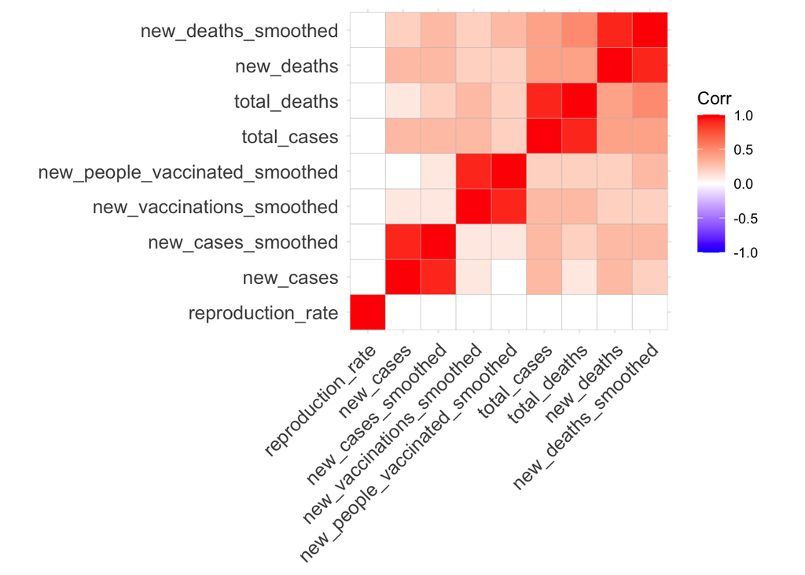

```r
# Compute a correlation matrix
corr <- round(cor(numerical_data), 1)

# Compute a matrix of correlation p-values
p.mat <- cor_pmat(numerical_data)

# Reordering the correlation matrix using hierarchical clustering
ggcorrplot(corr, hc.order = TRUE)
```

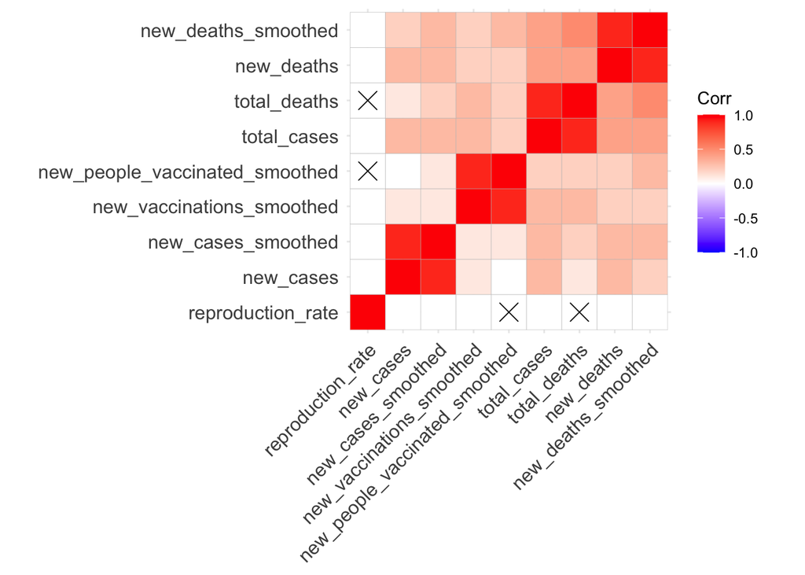

```r
# Barring the no significant coefficient
ggcorrplot(corr, hc.order = TRUE, p.mat = p.mat)
```

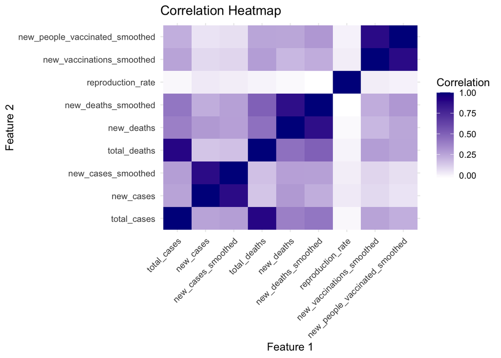

```r
# Calculate the correlation matrix
correlation_matrix <- cor(numerical_data)

# Reshape the correlation matrix for plotting
correlation_data <- as.data.frame(as.table(correlation_matrix))
colnames(correlation_data) <- c("Feature1", "Feature2", "Correlation")

# Create a heatmap of the correlation matrix with rotated x-axis labels
ggplot(data = correlation_data, aes(x = Feature1, y = Feature2, fill = Correlation)) +
  geom_tile() +
  scale_fill_gradient(low = "white", high = "darkblue") +
  labs(title = "Correlation Heatmap", x = "Feature 1", y = "Feature 2") +
  theme_minimal() +
  theme(axis.text.x = element_text(angle = 45, hjust = 1))
```

### E. Graphics and descriptive understanding should be provided along with Data Exploratory analysis (EDA). Identify subgroups of features that can explore some interesting facts.

#### Total Deaths Per Continent

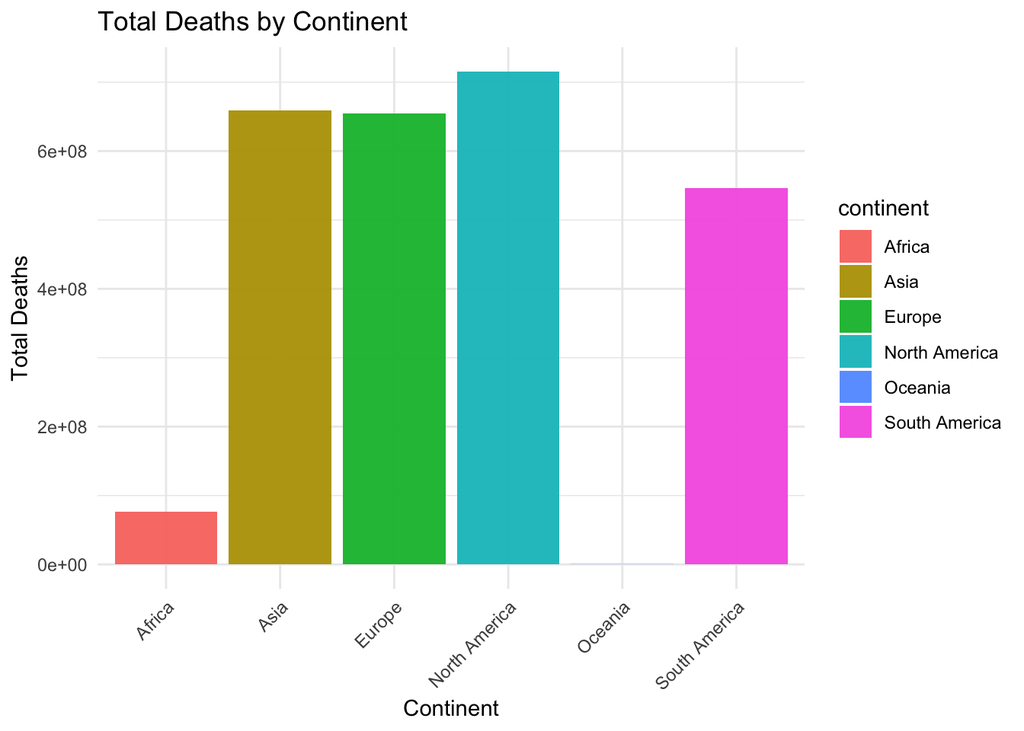

```r
# Group data by continent and calculate total deaths for each continent
continent_deaths <- data %>%
  group_by(continent) %>%
  summarise(total_deaths = sum(total_deaths, na.rm = TRUE))

# Create a bar chart of total deaths by continent
ggplot(data = continent_deaths, aes(x = continent, y = total_deaths, fill = continent)) +
  geom_bar(stat = "identity") +
  labs(title = "Total Deaths by Continent", x = "Continent", y = "Total Deaths") +
  theme_minimal() +
  theme(axis.text.x = element_text(angle = 45, hjust = 1)) # Rotate x-axis labels for better readability
```

#### Total Cases Per Cotinent

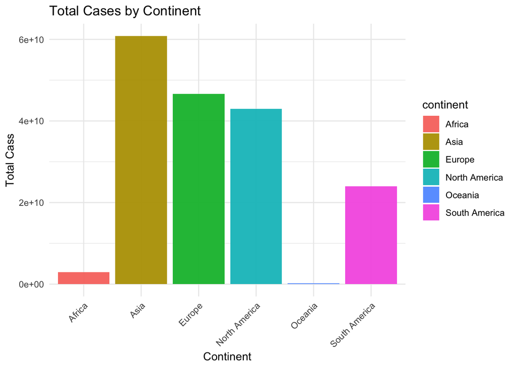

```r
# Group data by continent and calculate total cases for each continent
continent_cases <- data %>%
  group_by(continent) %>%
  summarise(total_cases = sum(total_cases, na.rm = TRUE))

# Create a ber chart of total cases by continent
ggplot(data = continent_cases, aes(x = continent, y = total_cases, fill = continent)) +
  geom_bar(stat = "identity") +
  labs(title = "Total Cases by Continent", x = "Continent", y = "Total Cass") +
  theme_minimal() +
  theme(axis.text.x = element_text(angle = 45, hjust = 1)) # Rotate x-axis labels for better readability
```

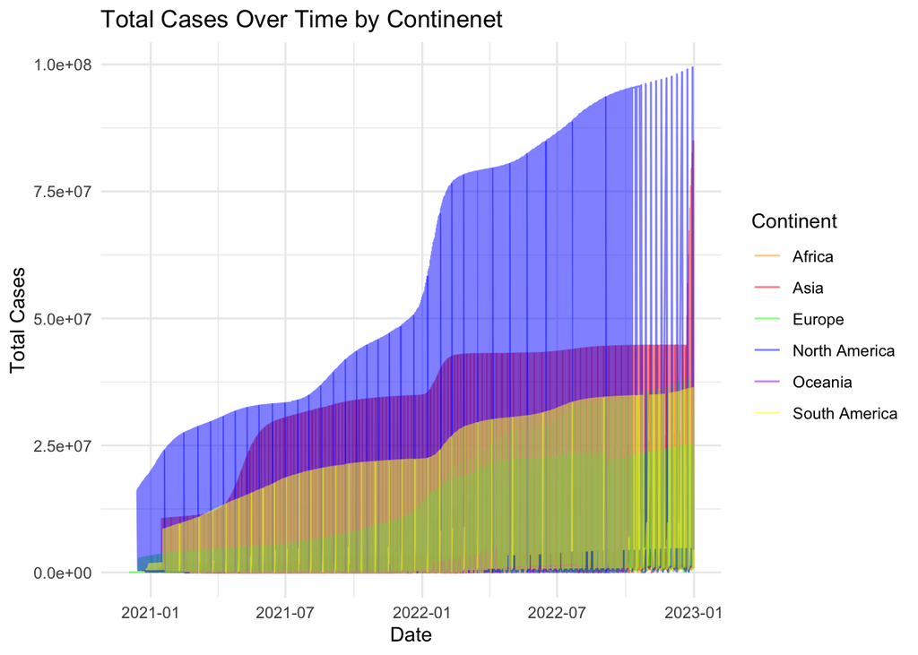

```r
# Manually specify colors for the continents
continent_colors <- c("Asia" = "red", "Africa" = "orange", "Europe" = "green",
                      "North America" = "blue", "Oceania" = "purple", "South America" = "yellow")

# Plot line chart of 'total_cases' over time per continent with manual colors and increased transparency
ggplot(data, aes(x = date, y = total_cases, color = continent)) +
  geom_line(alpha = 0.5) +   # Set the alpha value (transparency) to 0.5
  scale_color_manual(values = continent_colors) +
  labs(title = "Total Cases Over Time by Continenet", x = "Date", y = "Total Cases", color = "Continent") +
  theme_minimal()
```

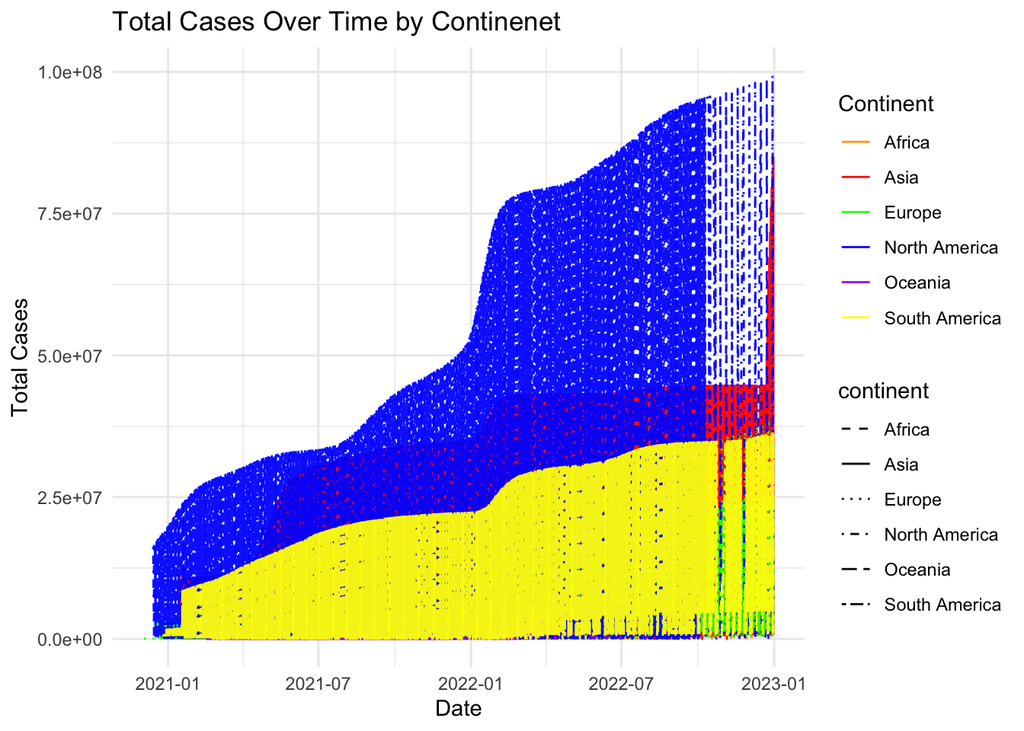

```r
ggplot(data, aes(x = date, y = total_cases, color = continent, linetype = continent)) +
  geom_line() +
  scale_color_manual(values = continent_colors) +
  scale_linetype_manual(values = c("Asia" = "solid", "Africa" = "dashed", "Europe" = "dotted",
                      "North America" = "dotdash", "Oceania" = "longdash", "South America" = "twodash")) +
labs(title = "Total Cases Over Time by Continenet", x = "Date", y = "Total Cases", color = "Continent") +
  theme_minimal()
```

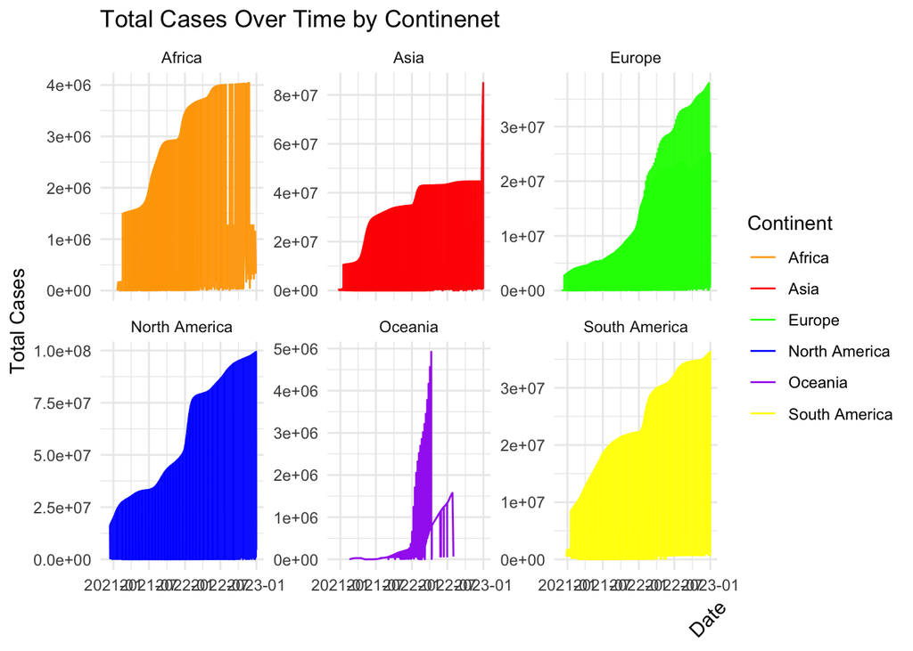

```r
ggplot(data, aes(x = date, y = total_cases, color = continent)) +
  geom_line() +
  scale_color_manual(values = continent_colors) +
  facet_wrap(~continent, scales = "free_y") +
  labs(title = "Total Cases Over Time by Continenet", x = "Date", y = "Total Cases", color = "Continent") +
  theme_minimal() +
  theme(axis.title.x = element_text(angle = 45, hjust = 1))
```